# exemplar

yjia0666

2026-10-18

```r
library(dplyr)
library(emmeans)
library(car)
library(dagitty)
library(knitr)
library(kableExtra)
library(ggplot2)
```

```r
data <- readRDS("shared_df_filter.rds")
```

# 1 Research Question

Our research question is: What is the association of alcohol consumption and CKD, and does sex modify this association?

The objective of this study is to investigate the association between alcohol consumption and CKD and to examine whether this association differs by sex. The findings aim to contribute to public health education by improving understanding of the potential relationship between alcohol consumption and CKD.

# 2 Data Preparation

## 2.1 Overview

The key variables included in the dataset for the subsequent analysis are summarised in the table below

Overview of Study Variables

| Variable | Description | Type | Role |
| --- | --- | --- | --- |
| CKD | Chronic kidney disease status (0 = No, 1 = Yes) | Binary categorical | Outcome |
| Alcohol_quantity | Number of standard drinks consumed in the last week | Numeric | Main exposure |
| Alcohol_frequency | Number of days per week consuming three or more drinks in a day over the past 12 months | Numeric | Additional alcohol-related predictor |
| Beer | Whether beer was consumed in the last week (0 = No, 1 = Yes) | Binary categorical | Additional alcohol-related predictor |
| Wine | Whether wine was consumed in the last week (0 = No, 1 = Yes) | Binary categorical | Additional alcohol-related predictor |
| Spirits_Liqueurs | Whether Spirits or liqueurs were consumed in the last week (0 = No, 1 = Yes) | Binary categorical | Additional alcohol-related predictor |
| Cider | Whether cider was consumed in the last week (0 = No, 1 = Yes) | Binary categorical | Additional alcohol-related predictor |
| Cocktails | Whether cocktail was consumed in the last week (0 = No, 1 = Yes) | Binary categorical | Additional alcohol-related predictor |
| Sex | Participant sex | Binary categorical | Effect modifier |
| Age | Participant age | Numeric | Potential confounder |

The following sections describe the data cleaning and preprocessing procedures used to prepare the dataset for analysis.

## 2.2 Data Cleaning and Removal

The original dataset contained two records with the same household identifier (ABSLID = “NHS11B0009794”) and person identifier (ABSPID = 6). Since ABSLID identifies a household and ABSPID identifies an individual within that household, each ABSLID–ABSPID combination was expected to be unique. However, further examination revealed differences in other variables between the two records, indicating that they were not exact duplicates. Both records were removed.

The alcohol type category “Other” was excluded because all observations in this category had a value of zero after data filtering.

Similarly, the alcohol frequency categories “No alcohol (past year)” and “Never alcohol” were excluded because they contained no participants (n = 0) in the filtered dataset.

## 2.3 Variable Transformation

Age was originally recorded as a categorical variable, with each category representing an age range. It was converted into a numeric variable by assigning the median age of each range to the corresponding observations. The dataset was additionally restricted to participants aged over 35 years, given that CKD is generally more prevalent in older populations and may develop progressively over time. This restriction was also explored as a potential way to improve class balance, however, the proportion of participants with CKD increased only slightly, from 10% to 11%.

Alcohol frequency was originally recorded as a categorical variable and was recoded into a numeric variable representing the number of days per week. Responses indicating a frequency of one day per week or more were retained at their original values, while less frequent responses were coded as zero. Unknown responses were retained as missing values (NA).

## 2.4 Alcohol Category Combination

The original dataset contained multiple alcohol types. To simplify the analysis and improve the interpretability of the results, similar alcohol types were combined into broader categories based on their characteristics.

# 3 Logistic Regression

## 3.1 Method Selection

Logistic regression was selected because the outcome variable CKD is binary. This method estimates the association between alcohol consumption and the odds of CKD while adjusting for other variables included in the model.

## 3.2 Model Specification

```r
model_int <- glm(CKD ~ Age + Alcohol_quantity * Sex + Alcohol_frequency + Beer + Wine + Spirits_Liqueurs + Cider + Cocktails, data = data, family = binomial)
```

$$\begin{aligned}
\log\left(\frac{P(CKD_i=1)}{1-(P(CKD_i=1))}\right)
={}& \beta_0 + \beta_1 \mathrm{Age}_i \\
&+ \beta_2 \mathrm{AlcoholQuantity}_i \\
&+ \beta_3 \mathrm{Sex}_i \\
&+ \beta_4 (\mathrm{AlcoholQuantity}_i \times \mathrm{Sex}_i) \\
&+ \beta_5 \mathrm{AlcoholFrequency}_i \\
&+ \beta_6 \mathrm{Beer}_i \\
&+ \beta_7 \mathrm{Wine}_i \\
&+ \beta_8 \mathrm{SpiritsLiqueurs}_i \\
&+ \beta_9 \mathrm{Cider}_i \\
&+ \beta_{10} \mathrm{Cocktails}_i
\end{aligned}$$

We used multivariable logistic regression to examine the association between alcohol consumption and CKD. CKD was the binary outcome, alcohol quantity was the primary exposure, and sex was included as a potential effect modifier. The model adjusted for age, alcohol consumption frequency, and types of alcohol consumed (beer, wine, spirits/liqueurs, cider, and cocktails). An interaction term between alcohol quantity and sex was included to assess whether the association differed by sex. The model is presented above in R code and mathematical form.

## 3.3 Assumptions and Diagnostics

### 3.3.1 Binary Outcome

The outcome variable CKD is binary, coded as 0 for absence of CKD and 1 for presence of CKD. Therefore, binary logistic regression is appropriate for this analysis.

### 3.3.2 Independence of observations

Each participant contributes one observation, and the data come from different individuals. Therefore, the observations are assumed to be independent.

### 3.3.3 Linearity in the logit

The linearity in the logit assumption means that continuous predictors have a linear relationship with the log odds of CKD. In this model, alcohol quantity, age, and alcohol frequency are numeric variables. Although age and alcohol frequency are discrete variables, they are treated as continuous predictors when entered into the model as numeric values. Therefore, the linearity in the logit assumption needs to be checked for these variables.

The linearity in the logit assumption was assessed for alcohol quantity, age, and alcohol frequency using scatter plots with LOWESS smooth curves.

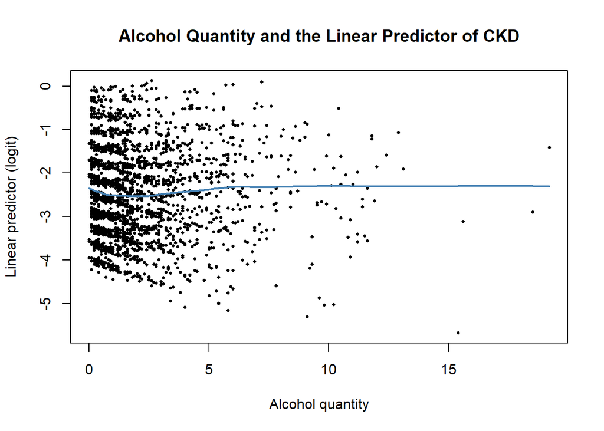

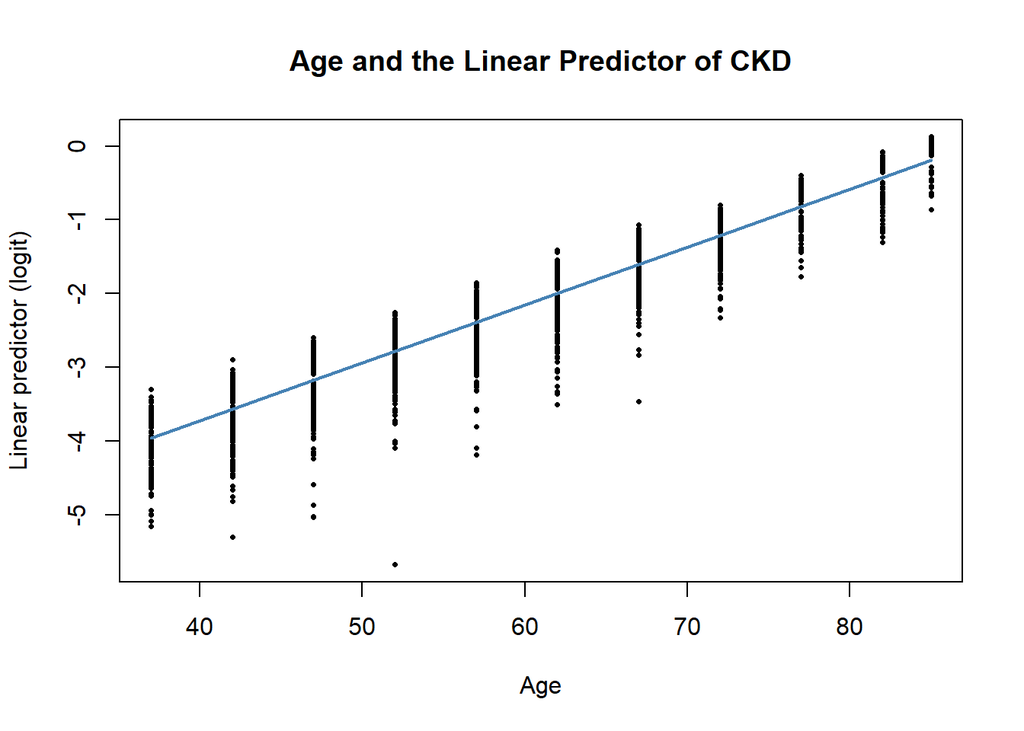

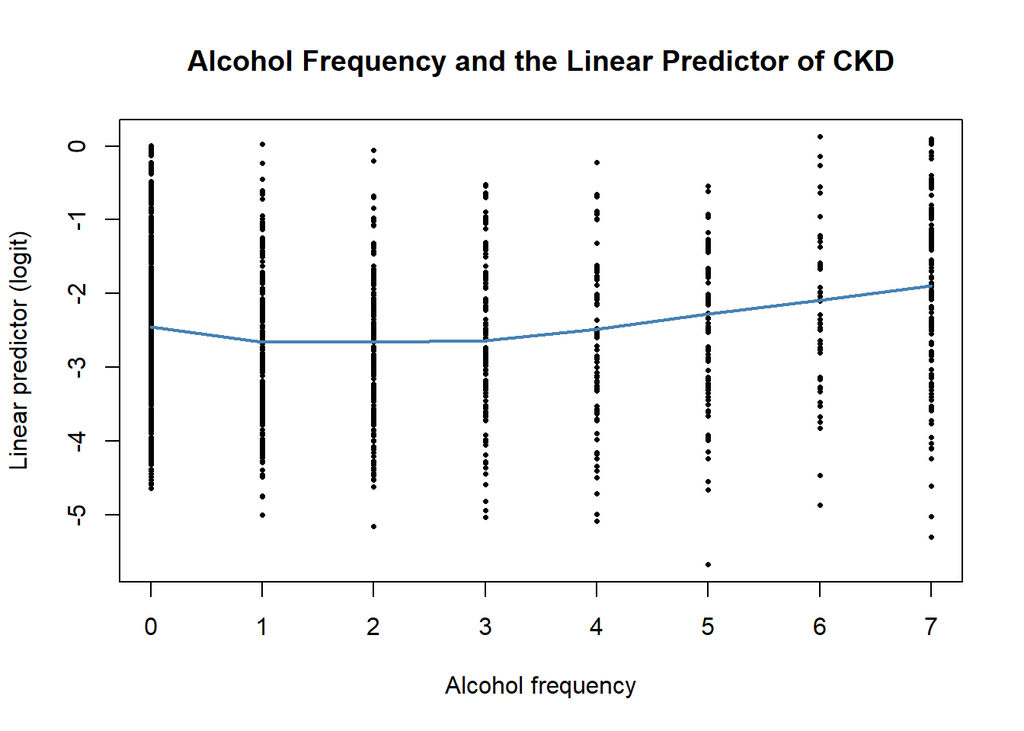

For alcohol quantity, the LOWESS curve shows an approximately linear relationship with the model’s linear predictor, with small deviations at lower levels. For age, the curve is almost a straight line. For alcohol frequency, the curve is also approximately linear, with a slight upward trend at higher frequencies.

Overall, the plots suggest that the linearity in the logit assumption is reasonably satisfied for all three variables.

### 3.3.4 Multicollinearity

```r
round(vif(model_int), 2)
```

```
##                  Age     Alcohol_quantity                  Sex
##                 1.04                11.00                 2.16
##    Alcohol_frequency                 Beer                 Wine
##                 2.10                 1.75                 1.53
##     Spirits_Liqueurs                Cider            Cocktails
##                 1.19                 1.02                 1.01
## Alcohol_quantity:Sex
##                12.15
```

Multicollinearity was assessed using the variance inflation factor (VIF). The VIF values ranged from 1.01 to 12.15, with the highest values observed for alcohol quantity (11.00) and the alcohol quantity × sex interaction term (12.15). The higher VIF for the interaction term may be related to its inclusion in the model, as interaction terms can increase VIF values.

```r
model_no_int <- glm(CKD ~ Age + Alcohol_quantity + Sex + Alcohol_frequency + Beer + Wine + Spirits_Liqueurs + Cider + Cocktails, data = data, family = binomial)
round(vif(model_no_int), 2)
```

```
##               Age  Alcohol_quantity               Sex Alcohol_frequency
##              1.04              2.14              1.31              2.05
##              Beer              Wine  Spirits_Liqueurs             Cider
##              1.73              1.54              1.18              1.02
##         Cocktails
##              1.01
```

For comparison, a model without the interaction term was fitted. The VIF values were lower in this model, particularly for alcohol quantity, suggesting that the interaction term may have contributed to the higher VIF values in the interaction model. As the interaction term was included to address the research question of whether the association differed by sex, it was retained in the model.

### 3.3.5 Influential Observations

Influential observations were assessed using Cook’s distance.

```r
cd <- cooks.distance(model_int)
```

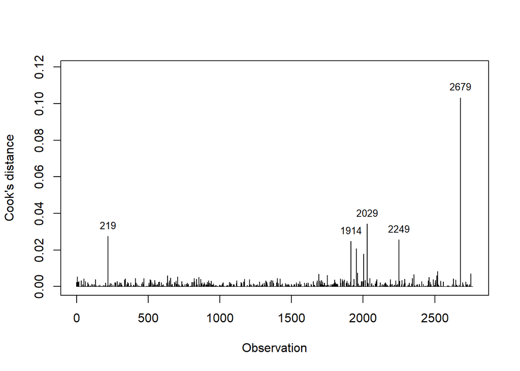

```r
top8_cd <- sort(cd, decreasing = TRUE)[1:8]
round(top8_cd, 4)
```

```
##   2679   2029    219   2249   1914   1952   2004   2520
## 0.1032 0.0342 0.0275 0.0255 0.0248 0.0207 0.0178 0.0083
```

Influential observations were assessed using Cook’s distance. Several observations had relatively higher Cook’s distances, the maximum value was 0.103.

The observations with higher Cook’s distances were examined in more detail.

```
##      Observation Cooks_Distance CKD Alcohol_quantity    Sex Age
## 2679        2679         0.1032   1              7.7   Male  37
## 2029        2029         0.0342   1             18.5   Male  42
## 219          219         0.0275   1              0.4 Female  42
## 2249        2249         0.0255   1              0.4 Female  52
## 1914        1914         0.0248   1              0.9   Male  52
## 1952        1952         0.0207   1              0.3 Female  72
## 2004        2004         0.0178   1              5.8 Female  72
##      Alcohol_frequency Beer Wine Spirits_Liqueurs Cider Cocktails
## 2679                 4    1    0                1     0         1
## 2029                 7    1    0                0     0         0
## 219                  0    0    0                1     1         0
## 2249                 0    0    1                0     1         0
## 1914                 0    0    0                0     1         0
## 1952                 0    0    0                0     1         0
## 2004                 7    1    1                0     0         0
```

After reviewing these observations individually, no data errors were identified, and all observations were retained in the analysis.

## 3.4 Results and Interpretation

```
##                  Variable   OR     95% CI    SE P-value
##               (Intercept) 0.00  0.00–0.00 0.414  <0.001
##                       Age 1.08  1.07–1.09 0.006  <0.001
##          Alcohol_quantity 0.83  0.68–1.00 0.098   0.053
##                   SexMale 1.24  0.85–1.81 0.192   0.255
##         Alcohol_frequency 1.02  0.94–1.10 0.040   0.645
##                     Beer1 0.96  0.69–1.34 0.170   0.821
##                     Wine1 0.90  0.65–1.24 0.163   0.508
##         Spirits_Liqueurs1 0.95  0.68–1.31 0.167   0.740
##                    Cider1 0.73  0.26–2.10 0.537   0.562
##                Cocktails1 1.31 0.17–10.28 1.053   0.800
##  Alcohol_quantity:SexMale 1.23  1.01–1.49 0.098   0.036
```

Age was positively associated with CKD, with the odds of CKD increasing by 8% for each one-year increase in age (OR = 1.08, p < 0.001). This finding is consistent with the expected relationship between age and CKD, as older age is an important risk factor for CKD.

Alcohol quantity showed a negative association with CKD among females (OR = 0.83, p = 0.053). Although the p-value was close to 0.05, the association was not statistically significant.This result suggests lower CKD odds with higher alcohol consumption, which may differ from the expectation, but the evidence is not strong enough to confirm this association.

Other alcohol-related variables, including alcohol frequency and different types of alcohol, were not significantly associated with CKD in the adjusted model.

Importantly, the interaction between alcohol quantity and sex was statistically significant (OR = 1.23, p = 0.036), suggesting that the association between alcohol quantity and CKD differed between males and females.

To further illustrate the regression results, the forest plot below shows the odds ratios and their 95% confidence intervals for the variables included in the model.

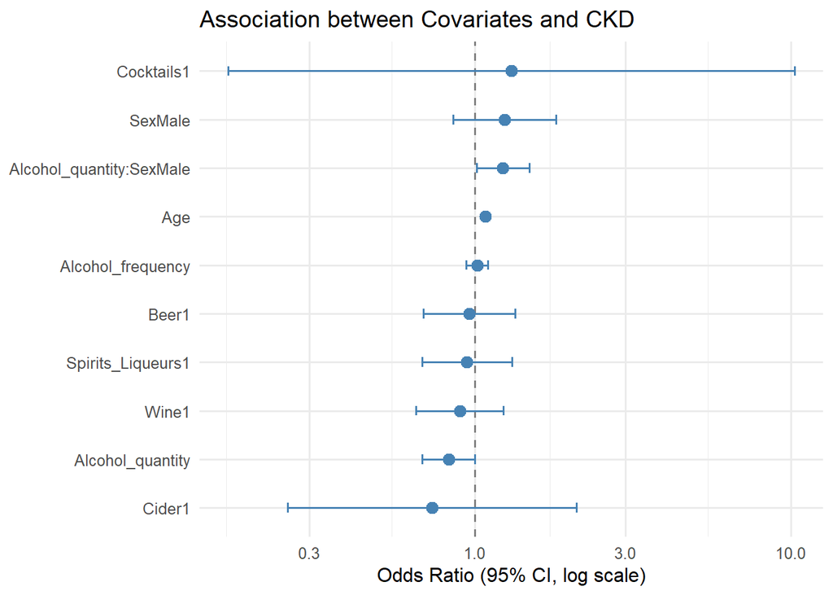

Age showed a clear positive association with CKD, and its narrow confidence interval suggested that the estimate was precise. Alcohol frequency also had a relatively narrow confidence interval, although its association with CKD was not statistically significant.

In contrast, Cider and Cocktails had wide confidence intervals, suggesting that their estimates were less precise and more uncertain.

The confidence interval for the interaction between alcohol quantity and sex did not include 1, providing further evidence that the association between alcohol quantity and CKD differed by sex.

The forest plot below compares the ORs and 95% CIs for the association between alcohol quantity and CKD in males and females.

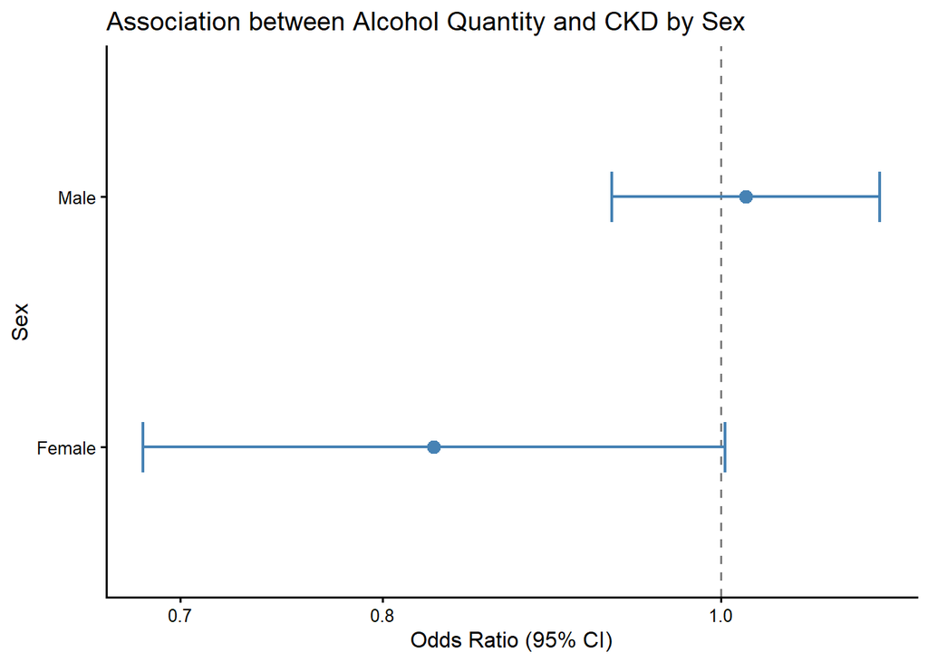

Among females, the OR was 0.83, suggesting lower odds of CKD with higher alcohol consumption, although this association was not statistically significant. In comparison, the OR for males was slightly above 1. The confidence interval was wider for females, indicating a less precise estimate. Overall, the plot illustrates the difference in the estimated associations between males and females, consistent with the statistically significant interaction (p = 0.036).

# 4 Conclusion

In conclusion, alcohol quantity, drinking frequency, and different types of alcohol were not significantly associated with CKD in the adjusted analyses. However, the association between alcohol quantity and CKD appeared to differ by sex. The significant interaction suggests that sex may modify the association between alcohol quantity and CKD. However, the results should be interpreted with caution due to the limitations of the data and the wide confidence intervals for some estimates.

## 4.1 Limitations

This study had several limitations. First, alcohol consumption was self-reported, so participants may not have recalled their drinking accurately.

Second, alcohol quantity and types were measured over the previous week, while drinking frequency was measured over the previous year. These different time frames may not reflect the same drinking patterns or fully capture long-term alcohol consumption, which may be more relevant to CKD.

In addition, some important confounding factors were not included in the model, which may have affected the results.

Furthermore, some categories within variables were combined, such as alcohol type and drinking frequency, so some differences may have been missed.

Finally, age was originally recorded in ranges and converted into numerical values using the median of each range. This may have reduced the accuracy of age measurement.

## 4.2 Future Research

Future research could use more detailed and reliable data on alcohol consumption to better reflect long-term drinking habits. More potential confounding factors could also be included in the model to improve the analysis. Finally, future studies with larger sample sizes could provide more precise estimates and help clarify whether sex modifies the association between alcohol consumption and CKD.

# References

Balci, Serdar. n.d. “Visualizing Regression Models with Forest Plots.” https://www.serdarbalci.com/jjstatsplot/articles/19-jforestmodel-comprehensive.html.

“Cook’s Distance Plot from Vector in r.” 2016. https://stackoverflow.com/questions/36543315/cooks-distance-plot-from-vector-in-r.

“Logistic Regression Assumptions and Diagnostics in r.” 2026. https://www.datanovia.com/learn/biostatistics/regression/logistic-regression-assumptions-and-diagnostics-in-r.

Weaver, Bruce. 2022. “Centering Continuous Predictors in Logistic Regression?” https://www.researchgate.net/post/Centering_Continuous_Predictors_in_Logistic_Regression.